# CNKClustering

3

1

```
# Wstęp do uczenia maszynowego - raport z II projektu
```

2

3

```
### Wojtek Kretowicz, Kacper Siemaszko
```

# Wstęp do uczenia maszynowego - raport z II projektu

### Wojtek Kretowicz, Kacper Siemaszko

1

1

```
## Wybrane zagadnienie
```

## Wybrane zagadnienie

1

1

```
Wybrany przez nas zbiór danych pochodzi z badania przeprowadzonego przez Centrum Nauki Kopernik na grupie 248 ankietowanych. Badanie dotyczyło związku pomiędzy postrzeganiem emocji a umiejętnością rozpoznawania ambiwalentnych wyrazów twarzy. Zbiór, do którego otrzymaliśmy dostęp składa się z trzech elementów - odpowiedzi ankietowanych, zdjęć do oceny oraz końcowej charakteryzacji ankietowanego pod względem sposobu postrzegania emocji. W naszym projekcie skupiliśmy się na pierwszym z tych elementów - odpowiedziach ankietowanych i ich demografii.
```

Wybrany przez nas zbiór danych pochodzi z badania przeprowadzonego przez Centrum Nauki Kopernik na grupie 248 ankietowanych. Badanie dotyczyło związku pomiędzy postrzeganiem emocji a umiejętnością rozpoznawania ambiwalentnych wyrazów twarzy. Zbiór, do którego otrzymaliśmy dostęp składa się z trzech elementów - odpowiedzi ankietowanych, zdjęć do oceny oraz końcowej charakteryzacji ankietowanego pod względem sposobu postrzegania emocji. W naszym projekcie skupiliśmy się na pierwszym z tych elementów - odpowiedziach ankietowanych i ich demografii.

5

1

```
## Cel analizy skupień
```

2

3

```
Na podstawie danych chcielibyśmy stwierdzić, czy po znalezieniu naturalnych skupień za pomocą algorytmów klastrujących otrzymamy grupy znacząco różniące się od siebie rozkładem płci i wieku.
```

4

5

## Cel analizy skupień

Na podstawie danych chcielibyśmy stwierdzić, czy po znalezieniu naturalnych skupień za pomocą algorytmów klastrujących otrzymamy grupy znacząco różniące się od siebie rozkładem płci i wieku.

1

1

```
## Postać danych
```

## Postać danych

1

1

```
Ponieważ do każdej cechy były cztery pytania, a każde pytanie dotyczyło losowej emocji, więć każdą cechę z agregowaliśmy do dwóch - jej średniej oraz rozstępu.
```

Ponieważ do każdej cechy były cztery pytania, a każde pytanie dotyczyło losowej emocji, więć każdą cechę z agregowaliśmy do dwóch - jej średniej oraz rozstępu.

|  | Wiek | Płeć | id_response | cechynieodzowne - zabawki vs książka wartosc | cechynieodzowne - zabawki vs książka rozstep | informacyjnosc - ssak vs Polak wartosc | informacyjnosc - ssak vs Polak rozstep | istota - Pies vs butelka wartosc | istota - Pies vs butelka rozstep | jednorodnosc - kamienie szlachetne vs krzesła wartosc | jednorodnosc - kamienie szlachetne vs krzesła rozstep | nieodwracalnosc - zwierzęta vs uczeń wartosc | nieodwracalnosc - zwierzęta vs uczeń rozstep | odrebnosc - drewno vs miękkie wartosc | odrebnosc - drewno vs miękkie rozstep | stabilnosc - owoce vs pieniądze wartosc | stabilnosc - owoce vs pieniądze rozstep |
| --- | --- | --- | --- | --- | --- | --- | --- | --- | --- | --- | --- | --- | --- | --- | --- | --- | --- |
| 0 | 23 | 1 | 41 | 4.75 | 7 | 8.00 | 3 | 10.00 | 0 | 7.75 | 4 | 4.00 | 6 | 6.25 | 9 | 1.50 | 6 |
| 1 | 20 | 0 | 42 | 4.00 | 5 | 3.00 | 3 | 6.75 | 2 | 6.50 | 5 | 6.50 | 4 | 6.00 | 4 | 6.75 | 1 |
| 2 | 38 | 1 | 67 | 7.25 | 8 | 4.25 | 3 | 5.00 | 0 | 9.50 | 2 | 6.25 | 10 | 9.50 | 2 | 5.25 | 8 |
| 3 | 17 | 0 | 43 | 4.75 | 5 | 6.00 | 3 | 5.25 | 8 | 5.75 | 3 | 5.50 | 4 | 7.00 | 3 | 6.25 | 4 |
| 4 | 17 | 0 | 45 | 4.25 | 9 | 5.75 | 6 | 7.50 | 10 | 4.25 | 6 | 6.00 | 8 | 5.25 | 7 | 5.75 | 10 |

1

1

```
## Postać danych do analizy
```

## Postać danych do analizy

1

1

```
Ze zbioru danych usunęliśmy $id$, bo jest to klucz zastępczy oraz $Wiek$ i $Płeć$, ponieważ to do nich będziemy przyrównywać naszą klasteryzację. Zbiór danych składa się z uśrednionych cech oraz ich rozstępów.
```

Ze zbioru danych usunęliśmy $id$, bo jest to klucz zastępczy oraz $Wiek$ i $Płeć$, ponieważ to do nich będziemy przyrównywać naszą klasteryzację. Zbiór danych składa się z uśrednionych cech oraz ich rozstępów.

|  | cechynieodzowne - zabawki vs książka wartosc | cechynieodzowne - zabawki vs książka rozstep | informacyjnosc - ssak vs Polak wartosc | informacyjnosc - ssak vs Polak rozstep | istota - Pies vs butelka wartosc | istota - Pies vs butelka rozstep | jednorodnosc - kamienie szlachetne vs krzesła wartosc | jednorodnosc - kamienie szlachetne vs krzesła rozstep | nieodwracalnosc - zwierzęta vs uczeń wartosc | nieodwracalnosc - zwierzęta vs uczeń rozstep | odrebnosc - drewno vs miękkie wartosc | odrebnosc - drewno vs miękkie rozstep | stabilnosc - owoce vs pieniądze wartosc | stabilnosc - owoce vs pieniądze rozstep |
| --- | --- | --- | --- | --- | --- | --- | --- | --- | --- | --- | --- | --- | --- | --- |
| 0 | 4.75 | 7 | 8.00 | 3 | 10.00 | 0 | 7.75 | 4 | 4.00 | 6 | 6.25 | 9 | 1.50 | 6 |
| 1 | 4.00 | 5 | 3.00 | 3 | 6.75 | 2 | 6.50 | 5 | 6.50 | 4 | 6.00 | 4 | 6.75 | 1 |
| 2 | 7.25 | 8 | 4.25 | 3 | 5.00 | 0 | 9.50 | 2 | 6.25 | 10 | 9.50 | 2 | 5.25 | 8 |
| 3 | 4.75 | 5 | 6.00 | 3 | 5.25 | 8 | 5.75 | 3 | 5.50 | 4 | 7.00 | 3 | 6.25 | 4 |
| 4 | 4.25 | 9 | 5.75 | 6 | 7.50 | 10 | 4.25 | 6 | 6.00 | 8 | 5.25 | 7 | 5.75 | 10 |

5

1

```
## Rozpatrywane algorytmy
```

2

3

```
* KMeans
```

4

```
* Spectral clustering
```

5

```
* Birch clustering
```

## Rozpatrywane algorytmy

- KMeans
- Spectral clustering
- Birch clustering

9

1

```
## Metodyka wyboru liczby klastrów
```

2

3

```
Do oszacowania liczby klastrów posłużyliśmy się trzema miarami oraz trzema algorytmami klasteryzacji, w których można wybrać liczbę klastrów.
```

4

5

```
1. minimalizacja indeksu Daviesa-Bouldina
```

6

7

```
2. maksymalizacja silhouette
```

8

9

```
3. minimalizacja Hubert's $\Gamma$ dla odległości między punktami wewnątrz klastrów
```

## Metodyka wyboru liczby klastrów

Do oszacowania liczby klastrów posłużyliśmy się trzema miarami oraz trzema algorytmami klasteryzacji, w których można wybrać liczbę klastrów.

1. minimalizacja indeksu Daviesa-Bouldina
2. maksymalizacja silhouette
3. minimalizacja Hubert's $\Gamma$ dla odległości między punktami wewnątrz klastrów

1

1

```
## Kmeans clustering
```

## Kmeans clustering

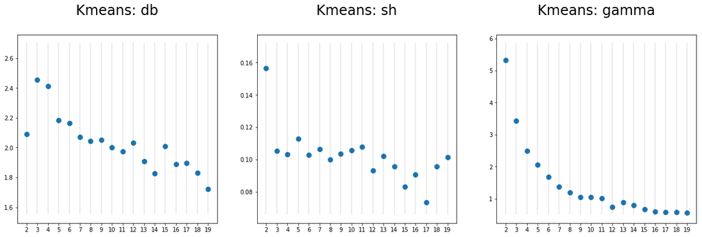

1

1

```
Algorytm zastosowaliśmy kilkukrotnie i za każdym razem wyniki pokrywały się w około $99\%$. $KMeans$ sugeruje istnienie 5 klastrów, z uwagi na pik w miarze silhouette oraz **łokieć** w gammie.
```

Algorytm zastosowaliśmy kilkukrotnie i za każdym razem wyniki pokrywały się w około $99\%$. $KMeans$ sugeruje istnienie 5 klastrów, z uwagi na pik w miarze silhouette oraz **łokieć** w gammie.

1

1

```
# Spectral clustering
```

# Spectral clustering

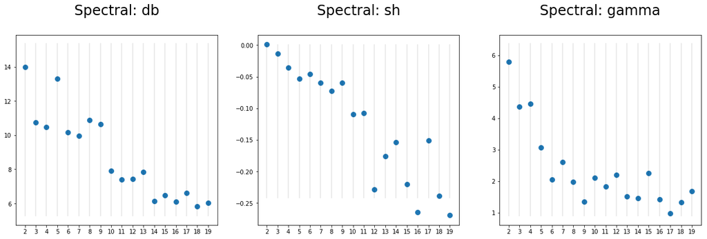

1

1

```
Jak będzie widać na wykresie poniżej oraz widać bezpośrednio z tych miar, ten algorytm źle klasteryzuje nasz zbiór danych. Zgodnie z zaleceniem sprawdziliśmy działanie spectral clusteringu dla różnych parametrów algorytmu - znalezione klastry były bardziej zrównoważone pod względem wielkości, ale przydzielenie etykiet nie różniło się od losowego przydziału.
```

Jak będzie widać na wykresie poniżej oraz widać bezpośrednio z tych miar, ten algorytm źle klasteryzuje nasz zbiór danych. Zgodnie z zaleceniem sprawdziliśmy działanie spectral clusteringu dla różnych parametrów algorytmu - znalezione klastry były bardziej zrównoważone pod względem wielkości, ale przydzielenie etykiet nie różniło się od losowego przydziału.

1

1

```
# Birch clustering
```

# Birch clustering

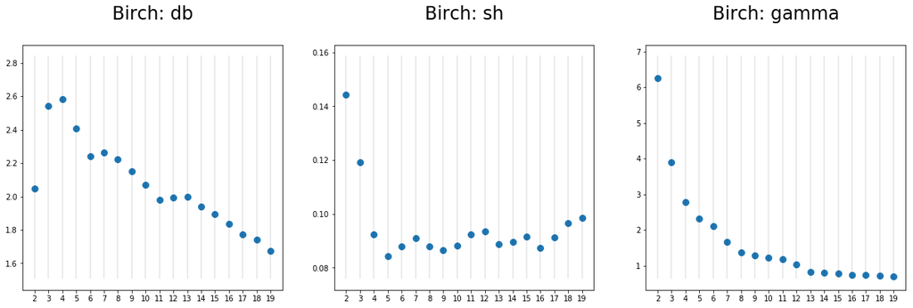

3

1

```
Ponieważ $Birch$ jest algorytmem deterministycznym, dawał najstabilniejsze i najlepiej interpretowalne wyniki. Analiza metryk sugeruje istnienie $5$ lub $6$ klastrów.
```

2

3

```
Poniżej widać dekompozycję przestrzeni przy użyciu algorytmu PCA na dwie główne składowe. Pierwsza składowa opiera się głównie na rozstępach cech.
```

Ponieważ $Birch$ jest algorytmem deterministycznym, dawał najstabilniejsze i najlepiej interpretowalne wyniki. Analiza metryk sugeruje istnienie $5$ lub $6$ klastrów.

Poniżej widać dekompozycję przestrzeni przy użyciu algorytmu PCA na dwie główne składowe. Pierwsza składowa opiera się głównie na rozstępach cech.

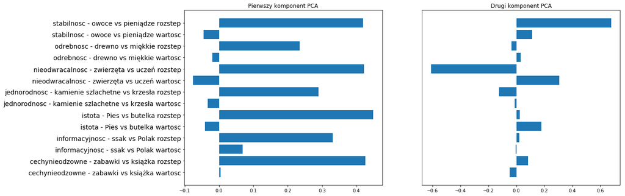

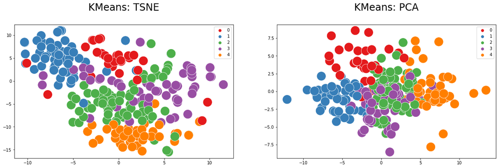

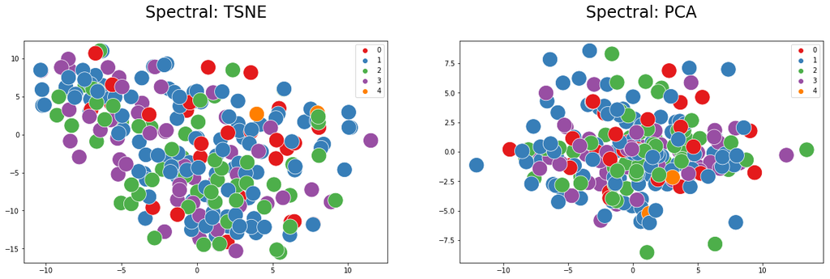

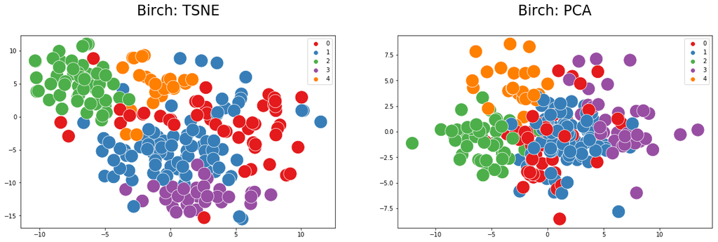

1

1

```
**KMeans** oraz **Birch** dokonują podobnej kalsteryzacji, podczas gdy klasteryzacja **Spectral** sprawia wrażenie losowej. Klasteryzacja hierarchiczna z łączeniem kompletnym (*complete linkage*), której wykres widać poniżej również dzieli zbiór danych na $5$ *pełnych* klastrów oraz $3$ zdegenerowane.
```

**KMeans** oraz **Birch** dokonują podobnej kalsteryzacji, podczas gdy klasteryzacja **Spectral** sprawia wrażenie losowej. Klasteryzacja hierarchiczna z łączeniem kompletnym (*complete linkage*), której wykres widać poniżej również dzieli zbiór danych na $5$ *pełnych* klastrów oraz $3$ zdegenerowane.

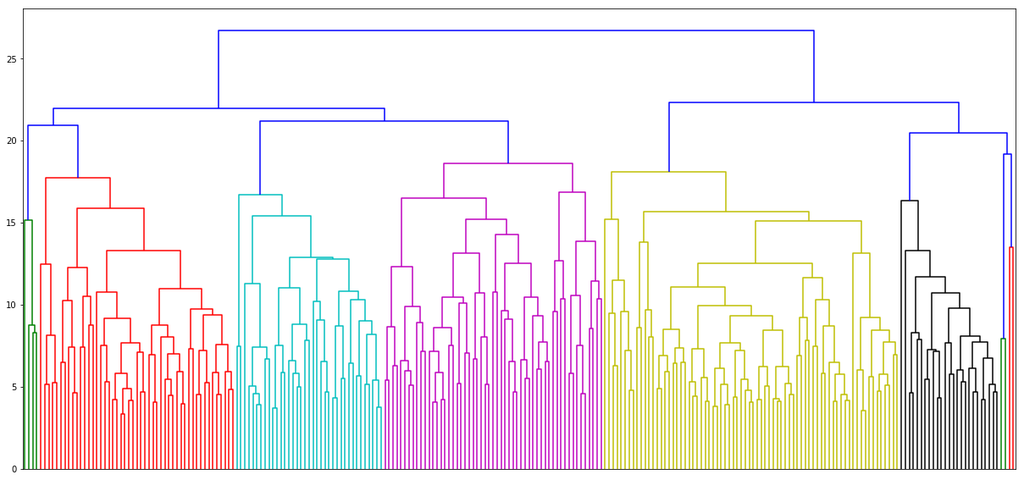

1

1

```
# Wyniki po standaryzacji
```

# Wyniki po standaryzacji

1

1

```
Z uwagi na dwa rodzaje kolumn dokonaliśmy klasteryzacji bez standaryzacji, lecz postanowiliśmy również sprawdzić, jak będzie ona przebiegała po wystandaryzowaniu.
```

Z uwagi na dwa rodzaje kolumn dokonaliśmy klasteryzacji bez standaryzacji, lecz postanowiliśmy również sprawdzić, jak będzie ona przebiegała po wystandaryzowaniu.

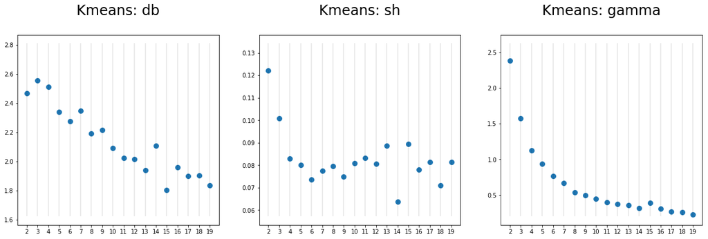

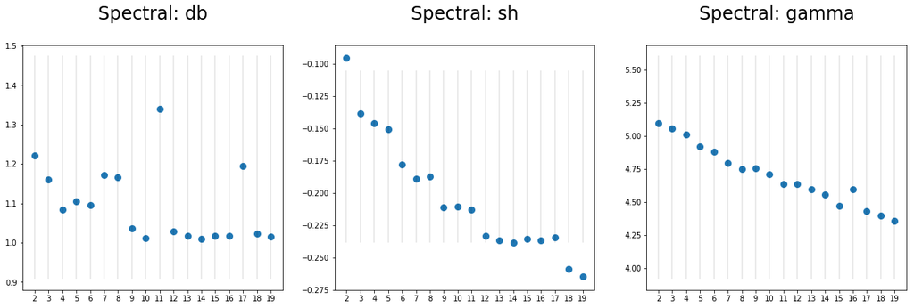

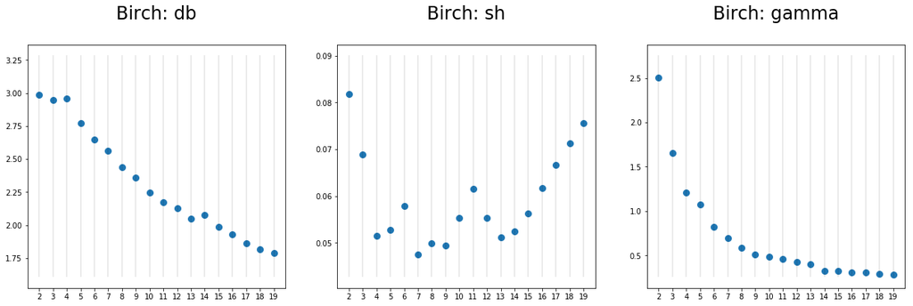

1

1

```
Przy wystandaryzowanych danych dla **Birch** optymalna liczba klastrów to $6$. Pierwszy komponent**PCA** podobnie jak dla niewystandaryzowanych danych skupia sięna rozstępach. Różnica pojawia się jednak w drugim komponencie, który odgrywa już tu większą rolę. Mimo wszystko klasteryzacja jest dokonywana głównie na podstawie rozstępów cech - czyli wahań ankietowanych.
```

Przy wystandaryzowanych danych dla **Birch** optymalna liczba klastrów to $6$. Pierwszy komponent**PCA** podobnie jak dla niewystandaryzowanych danych skupia sięna rozstępach. Różnica pojawia się jednak w drugim komponencie, który odgrywa już tu większą rolę. Mimo wszystko klasteryzacja jest dokonywana głównie na podstawie rozstępów cech - czyli wahań ankietowanych.

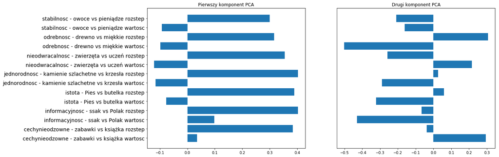

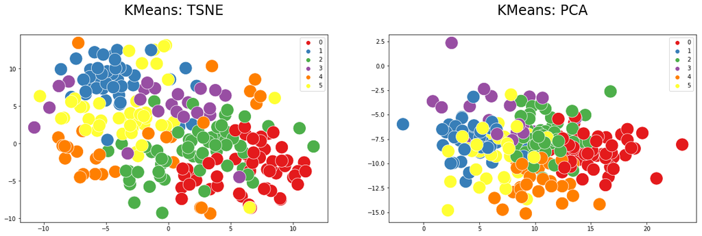

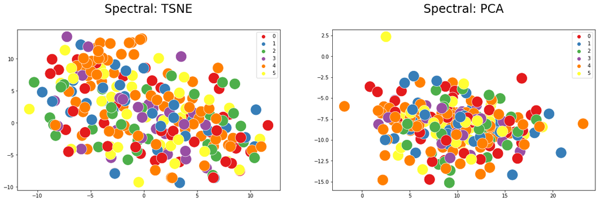

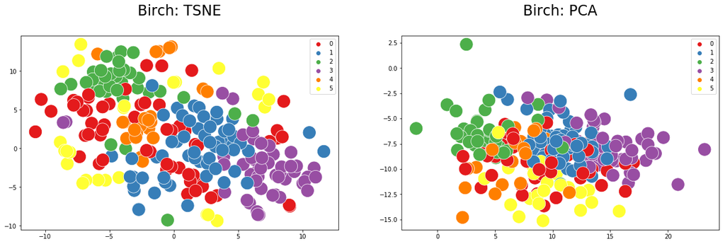

1

1

```
Podobnie jak dla niewystandaryzowanych danych **Birch** oraz **KMeans** zadziałały bardzo podobnie, podczas gdy **Spectral** dalej daje złą klasteryzację.
```

Podobnie jak dla niewystandaryzowanych danych **Birch** oraz **KMeans** zadziałały bardzo podobnie, podczas gdy **Spectral** dalej daje złą klasteryzację.

1

1

```
Po standaryzacji otrzymaliśmy $5$ klastrów w hierarchicznej analizie zbioru.
```

Po standaryzacji otrzymaliśmy $5$ klastrów w hierarchicznej analizie zbioru.

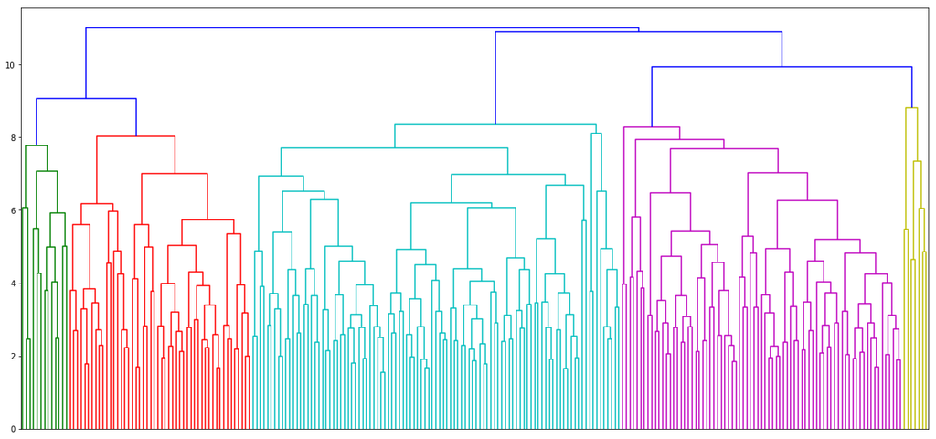

3

1

```
# Metoda automatycznego znajdowania liczby skupień - DBSCAN
```

2

3

```
Ten rodzaj klasteryzacji przeprowadziliśmy wielokrotnie dla wielu różnych hiperparametrów, ale za każdym razem wyniki nie różniły się między sobą w kontekście różnic w rozkładzie płci i wieku.
```

# Metoda automatycznego znajdowania liczby skupień - DBSCAN

Ten rodzaj klasteryzacji przeprowadziliśmy wielokrotnie dla wielu różnych hiperparametrów, ale za każdym razem wyniki nie różniły się między sobą w kontekście różnic w rozkładzie płci i wieku.

```
DBSCAN(algorithm='auto', eps=2.46, leaf_size=12, metric='euclidean',
    metric_params=None, min_samples=12, n_jobs=None, p=None)
```

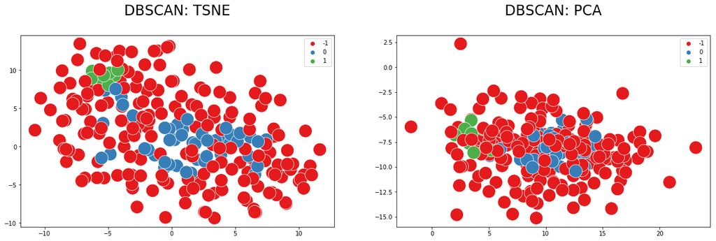

1

1

```
# Różnice w rozkładzie płci
```

# Różnice w rozkładzie płci

1

1

```
plt.figure(figsize=(20,10))
```

2

```
for i in range(6):
```

3

```
    plt.subplot(2,3,i+1)
```

4

```
    a = clusters[i].Płeć.value_counts()/clusters[i].shape[0]
```

5

```
    a.plot(kind='bar')
```

6

```
    plt.title(f'Skupienie nr {i}', size=24)
```

7

```
    plt.ylim(0,1)
```

8

```
    plt.hlines(0.5,-1,2,alpha = 0.4, color = 'red')
```

9

```
plt.show()
```

executed in 520ms, finished 13:45:07 2019-06-16

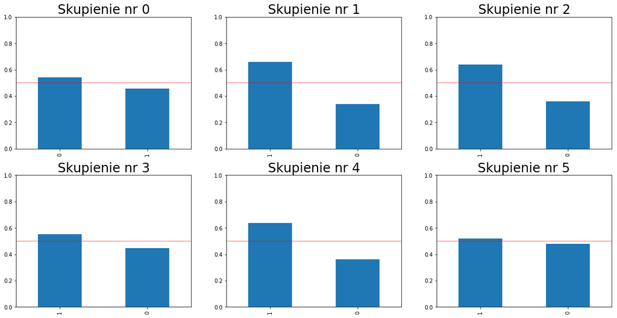

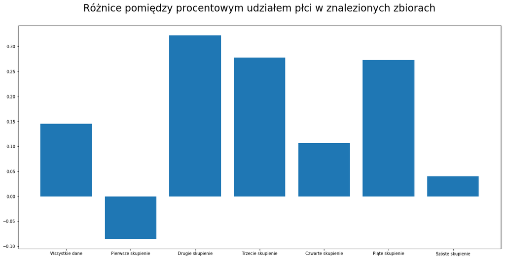

1

1

```
# Różnice w rozkładzie wieku
```

# Różnice w rozkładzie wieku

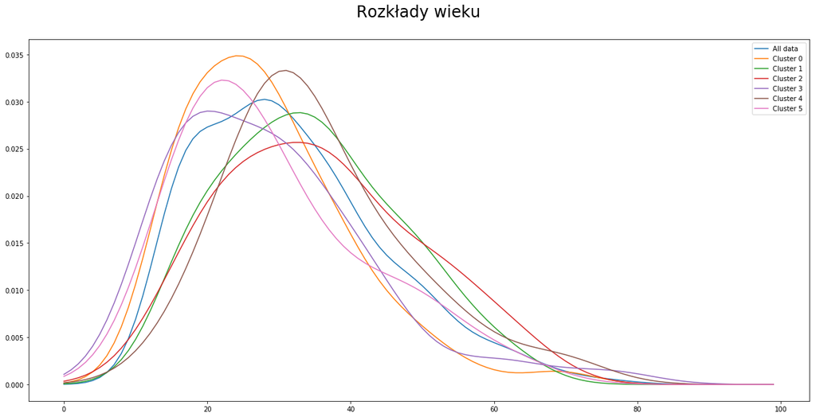

7

1

```
To jest określenie dominującego klastra w danym koszyku. Wartości w lewej kolumnie to płeć, wartości w prawej to skategoryzowany wiek. Ponieważ nie jest wiadome, która liczba oznacza którą płeć, przyjmijmy dla wygody opisu, że $0$ to kobieta, a $1$ to mężczyzna. Na podstawie tego można określić, że:
```

2

```
* klaster $0$ oznacza młode kobiety i starych mężczyzn
```

3

```
* klaster $1$ to osoby w średnim wieku
```

4

```
* klaster $2$ to mężczyźni w średnim wieku oraz starsi
```

5

```
* klaster $3$ to starsze kobiety
```

6

7

```
Określenie kim są osoby w pozostałych dwóch klastrach oraz dokładniejsze rozróżnienie pierwszych $4$ klastrów niosłaby pewnie dodatkowa zmienna.
```

To jest określenie dominującego klastra w danym koszyku. Wartości w lewej kolumnie to płeć, wartości w prawej to skategoryzowany wiek. Ponieważ nie jest wiadome, która liczba oznacza którą płeć, przyjmijmy dla wygody opisu, że $0$ to kobieta, a $1$ to mężczyzna. Na podstawie tego można określić, że:

- klaster $0$ oznacza młode kobiety i starych mężczyzn
- klaster $1$ to osoby w średnim wieku
- klaster $2$ to mężczyźni w średnim wieku oraz starsi
- klaster $3$ to starsze kobiety

Określenie kim są osoby w pozostałych dwóch klastrach oraz dokładniejsze rozróżnienie pierwszych $4$ klastrów niosłaby pewnie dodatkowa zmienna.

```
0 0 :  0
0 1 :  0
0 2 :  0
0 3 :  1
0 4 :  0
0 5 :  1
0 6 :  1
0 7 :  3
1 0 :  0
1 1 :  1
1 2 :  1
1 3 :  2
1 4 :  1
1 5 :  1
1 6 :  2
1 7 :  0
```

3

1

```
# Podsumowanie
```

2

3

```
Przy tak dobranej liczbie klastrów możemy zauważyć, że skupienia różnią się rozkładami płci i wieku. Wydaje się, że gdybyśmy dysponowali jeszcze jedną zmienną oprócz płci i wieku, wybrane klastry można by jednoznacznie nazwać.
```

# Podsumowanie

Przy tak dobranej liczbie klastrów możemy zauważyć, że skupienia różnią się rozkładami płci i wieku. Wydaje się, że gdybyśmy dysponowali jeszcze jedną zmienną oprócz płci i wieku, wybrane klastry można by jednoznacznie nazwać.